# 第7回 習熟度確認と復習（1）：可視化・整形までの操作確認

行動計量学（行動科学分析法入門）

小野原 彩香

令和8年度

← 授業トップへ戻る

> **この回は11月27日（金）に行います。** 当初の予定（11月20日）から1週間後ろにずれました。 担当教員がインフルエンザで出勤停止となったため，**第7回と第8回を入れ替えた**ことによります。
> - **11月20日（金）** … 第8回「相関分析と散布図」を**遠隔オンデマンド**（教室には集まりません）
> - **11月27日（金）** … この回。**習熟度確認テスト1はこの日**です（対面・W201）

> 出題範囲・持ち物・参照してよいもの・AIの扱いは，先に知らせたとおりで**変更ありません。**

## 本日の流れ

1. **復習（前半）**：第2〜6回のポイントを確認
2. **習熟度確認テスト（後半）**：RStudio を使って課題に取り組む

## 復習：これまでの内容

### R・RStudioの基本（第2回）

```r
# 変数への代入
x <- 42
y <- c(1, 2, 3, 4, 5)

# 基本的な統計関数
mean(y)
```

```
## [1] 3
```

```r
sd(y)
```

```
## [1] 1.581139
```

### データの可視化 - ggplot2（第3・4回）

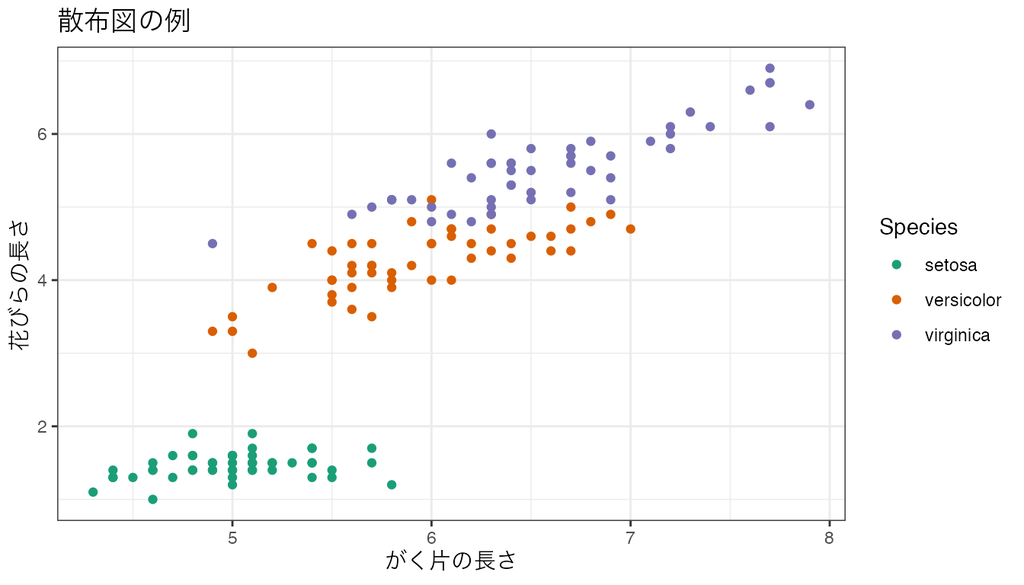

```r
# 散布図の基本
ggplot(data = iris, aes(x = Sepal.Length, y = Petal.Length, color = Species)) +
  geom_point() +
  scale_color_brewer(palette = "Dark2") +
  labs(title = "散布図の例", x = "がく片の長さ", y = "花びらの長さ") +
  theme_bw()
```

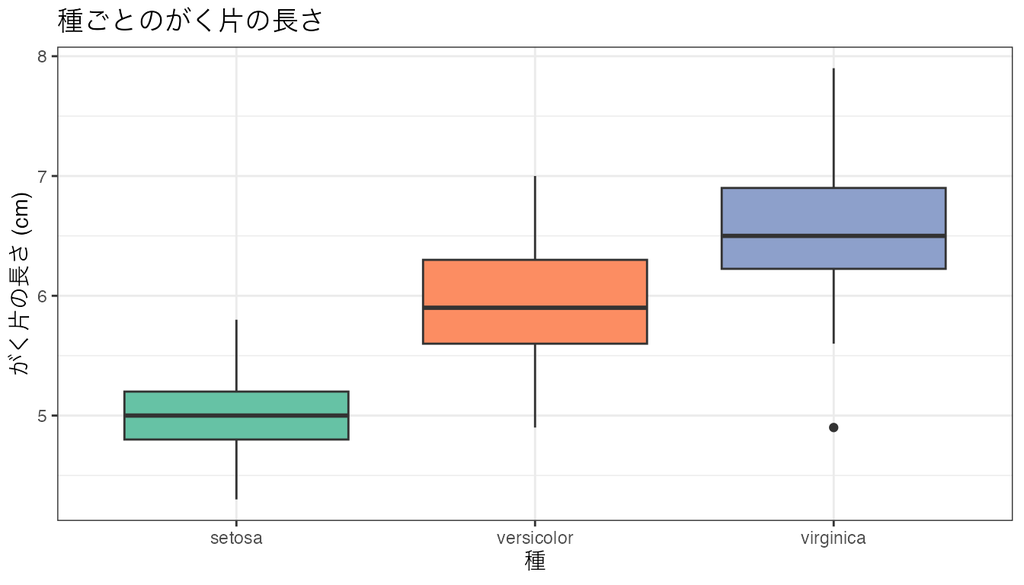

```r
# 箱ひげ図
ggplot(data = iris, aes(x = Species, y = Sepal.Length, fill = Species)) +
  geom_boxplot() +
  scale_fill_brewer(palette = "Set2") +
  labs(title = "種ごとのがく片の長さ", x = "種", y = "がく片の長さ (cm)") +
  theme_bw() +
  theme(legend.position = "none")
```

### データの加工 - dplyr（第5・6回）

```r
# filter + select + mutate + arrange の組み合わせ
iris |>
  filter(Species == "virginica") |>
  select(Sepal.Length, Sepal.Width, Petal.Length) |>
  mutate(sepal_ratio = Sepal.Length / Sepal.Width) |>
  arrange(desc(sepal_ratio)) |>
  head(5)
```

|  | Sepal.Length | Sepal.Width | Petal.Length | sepal_ratio |
| --- | --- | --- | --- | --- |
| 1 | 7.7 | 2.6 | 6.9 | 2.961538 |
| 2 | 7.7 | 2.8 | 6.7 | 2.750000 |
| 3 | 6.0 | 2.2 | 5.0 | 2.727273 |
| 4 | 6.7 | 2.5 | 5.8 | 2.680000 |
| 5 | 7.4 | 2.8 | 6.1 | 2.642857 |

```r
# group_by + summarise
iris |>
  group_by(Species) |>
  summarise(
    n    = n(),
    mean = mean(Petal.Length),
    sd   = sd(Petal.Length)
  )
```

| Species | n | mean | sd |
| --- | --- | --- | --- |
| setosa | 50 | 1.462 | 0.1736640 |
| versicolor | 50 | 4.260 | 0.4699110 |
| virginica | 50 | 5.552 | 0.5518947 |

## よくある間違いと対処法

| エラー | 原因 | 対処法 |
| --- | --- | --- |
| `could not find function` | パッケージを読み込んでいない | `library(tidyverse)` を実行 |
| `object not found` | 変数名が間違っている | スペル・大文字小文字を確認 |
| `unexpected ')'` | 括弧が合っていない | 括弧の数をチェック |
| グラフが表示されない | データが空など | `str()` / `head()` でデータを確認 |
| `NA` が返ってくる | 欠損値が含まれている | `na.rm = TRUE` を追加 |

## 習熟度確認テスト（第1回）

**問題は授業当日に配布します。**

この回は前半が復習，後半が習熟度確認テストです。 テストは RStudio で実際にデータを分析し，作成した `.R` スクリプトを提出する形式で行います。 出題範囲は，上の復習部分で扱った内容です。

> **当日までに，次の2つを済ませておいてください。**
> 1. **プロジェクトフォルダを用意しておく**（第3回の0-1）。 **当日，CSVファイルを1つ配布します。** それを読み込む問題が出ます
> 2. **`library(tidyverse)` が通ることを確認しておく**。当日その場で `install.packages()` から始めると，時間が足りません

> ファイルの読み込みでつまずいた場合でも，**他の問題は組み込みデータで解けます。** 手が止まったままにならないよう，当日の冒頭で代替のしかたを案内します。

> 問題と解答例は，**12月4日（金）**にこのページへ掲載します（テストの1週間後，第9回の日）。 当日どうしても都合がつかない人のために，**12月3日（木）23:59 まで**提出を受け付けるためです。

## 提出方法

- 作成した R スクリプト（`.R` ファイル）を保存する
- ファイル名：`習熟度確認1_学籍番号.R`
- 提出先：授業内で案内します

## この回で使った関数

出てきた順に並べています。**（）の中に何を入れるか**を確かめたいときに見てください。

| 関数 | すること | （）の中に入れるもの | 例 |
| --- | --- | --- | --- |
| `library()` | パッケージを読み込む | パッケージ名。**引用符なし** | `library(tidyverse)` |
| `c()` | 複数の値を1つに束ねる | 束ねたい値を `,` で並べる | `c(85, 72, 91)` |
| `mean()` | 平均 | 数値の列。欠損があるときは `na.rm = TRUE` | `mean(iris$Sepal.Length)` |
| `sd()` | 標準偏差 | 数値の列。欠損があるときは `na.rm = TRUE` | `sd(iris$Sepal.Length)` |
| `ggplot()` | グラフの土台を作る | `data =` データ, `aes()` で軸の割り当て | `ggplot(iris, aes(x = Sepal.Length, y = Petal.Length))` |
| `aes()` | 列をグラフの要素に割り当てる | `x =`, `y =`, `color =`, `fill =` など | `aes(x = Species, y = Petal.Length)` |
| `geom_point()` | 点を描く（散布図） | `size =`・`color =` など見た目（省略可） | `geom_point(size = 2)` |
| `scale_color_brewer()` | 点や線の色をColorBrewerの組にする | `palette = "Dark2"` など | `scale_color_brewer(palette = "Dark2")` |
| `labs()` | タイトルや軸ラベルを付ける | `title =`, `x =`, `y =`, `color =`, `fill =` | `labs(title = "花びらの長さ", x = "種", y = "長さ (cm)")` |
| `theme_bw()` | 白地に枠線の見た目にする | **何も入れません**（`base_family =` でフォント指定可） | `theme_bw()` |
| `geom_boxplot()` | 箱ひげ図を描く | 見た目の指定（省略可） | `geom_boxplot()` |
| `scale_fill_brewer()` | 塗りつぶしの色をColorBrewerの組にする | `palette = "Set2"` など | `scale_fill_brewer(palette = "Set2")` |
| `theme()` | 細かい見た目を個別に変える | `axis.text = element_text(...)` など | `theme(axis.text = element_text(size = 12))` |
| `filter()` | **行**を絞り込む | データ, 残す行の条件。`,` で並べると「かつ」 | `filter(msleep, sleep_total >= 12)` |
| `select()` | **列**を選ぶ | データ, 残す列名。頭に `-` で除外 | `select(msleep, name, vore)` |
| `mutate()` | 列を作る・書き換える | データ, `新しい列名 = 計算式` | `mutate(msleep, sleep_min = sleep_total * 60)` |
| `arrange()` | 並び替える | データ, 基準にする列。降順は `desc()` で包む | `arrange(msleep, desc(sleep_total))` |
| `desc()` | 降順にする | 列名（`arrange()` の中だけ） | `arrange(msleep, desc(bodywt))` |
| `head()` | 先頭の数行を取り出す | データ, 行数（省略すると6行） | `head(iris, 3)` |
| `group_by()` | グループに分ける | データ, 分ける基準の列 | `group_by(msleep, vore)` |
| `summarise()` | グループごとに1行にまとめる | データ, `新しい列名 = 集計の式` | `summarise(msleep, 平均 = mean(sleep_total))` |
| `n()` | そのグループの件数 | **何も入れません**（`n()` と書く） | `summarise(msleep, 件数 = n())` |

パイプ `|>` は関数ではなく記号です。`データ |> 関数()` と書くと， データがその関数の**1つめの（）の中身**として渡されます。

> **もっと詳しく知りたいときは** `?関数名` と実行してください（例：`?c`）。 右下の **Help** タブに，その関数の説明と，（）に書ける項目が全部出ます。 読み方は **第2回「ヘルプの読み方」** にまとめてあります。

## 本日のまとめ

- 第2〜6回の内容（Rの基本操作・可視化・加工）を復習した
- 習熟度確認テストで `filter()`, `select()`, `mutate()`, `arrange()`, `group_by()`, `summarise()`, `ggplot2` の操作を確認した

## 次回の予告

> 第8回（相関分析と散布図）は，**11月20日の遠隔オンデマンド回で扱います。** 第7回と第8回を入れ替えたことによります。

次回（第9回）は**カテゴリデータの分析（カイ二乗検定）**です。

教科書のカイ二乗検定に関する章を読んでおきましょう。

← 授業トップへ戻る